# Data Wrangling with R Project

## Background Information

MTN Telecom offers mobile and internet services to its customers. These services include phone, multiple lines, internet, online security, online backup, device protection, tech support, and streaming TV and movies. The management would like your assistance in understanding the subscribed customers. Your recommendations informed by your analysis will help them make decisions on effective customer retention programs.

## Dataset Information

The provided customer data set includes information about:

- Customers who left within the last month – the column is called Churn.
- The services that each customer has signed up for – phone, multiple lines, internet, online security, online backup, device protection, tech support, and streaming TV and movies.
- Customer account information – how long they’ve been a customer, contract, payment method, paperless billing, monthly charges, and total charges.
- The demographic information about customers – gender, age range, and if they have partners and dependents.

Each row represents a customer, and each column contains the customer’s attributes described on the column Metadata.

Dataset URL: https://bit.ly/2ZlpzjF

## Problem Statement

Read, explore, clean, and analyze the dataset.

## Experimental Design

- Install and Load Packages
- Import Data
- Data Understanding
- Standardisation
- Handle Irrelevant Data
- Find and Deal with Duplicates
- Find and Handle Missing data
- Find and Deal with Outliers

## Step 1. Install and Load Packages

In R, packages are a collection of functions that provide functinalities not given by the R core functionalities. We’ll install tidyverse packages which will provide us with packages for performing data manipulation and analysis.

Let’s install tidyverse packages in Rstudio

```r
install.packages("tidyverse")
```

Load tidyverse for use in our notebook

```r
library(tidyverse)
```

## Step 2. Import Data

To work with a dataset, we need to import it and understand its structure.

```r
customer_df <- read_csv("https://bit.ly/2ZlpzjF")
```

## Step 3. Data Understanding

```r
# Preview the first 6 records of the dataset
head(customer_df)
```

| customerID | GENDER | SeniorCitizen | PARTNER | Dependents | tenure | PhoneService | MultipleLines | InternetService | OnlineSecurity | OnlineBackup | DeviceProtection | TECHSUPPORT | StreamingTV | StreamingMovies | Contract | PaperlessBilling | PaymentMethod | MonthlyCharges | TotalCharges | Churn |
| --- | --- | --- | --- | --- | --- | --- | --- | --- | --- | --- | --- | --- | --- | --- | --- | --- | --- | --- | --- | --- |
| 7590-VHVEG | Female | 0 | Yes | No | 1 | No | No phone service | DSL | No | Yes | No | No | No | No | Month-to-month | Yes | Electronic check | 29.85 | 29.85 | No |
| 5575-GNVDE | Male | 0 | No | No | 34 | Yes | No | DSL | Yes | No | Yes | No | No | No | One year | No | Mailed check | 56.95 | 1889.50 | No |
| 3668-QPYBK | Male | 0 | No | No | 2 | Yes | No | DSL | Yes | Yes | No | No | No | No | Month-to-month | Yes | Mailed check | 53.85 | 108.15 | Yes |
| 7795-CFOCW | Male | 0 | No | No | 45 | No | No phone service | DSL | Yes | No | Yes | Yes | No | No | One year | No | Bank transfer (automatic) | 42.30 | 1840.75 | No |
| 9237-HQITU | Female | 0 | No | No | 2 | Yes | No | Fiber optic | No | No | No | No | No | No | Month-to-month | Yes | Electronic check | 70.70 | 151.65 | Yes |
| 9305-CDSKC | Female | 0 | No | No | 8 | Yes | Yes | Fiber optic | No | No | Yes | No | Yes | Yes | Month-to-month | Yes | Electronic check | 99.65 | 820.50 | Yes |

```r
NA
```

```r
# Preview the last 6 records of the dataset
tail(customer_df)
```

| customerID | GENDER | SeniorCitizen | PARTNER | Dependents | tenure | PhoneService | MultipleLines | InternetService | OnlineSecurity | OnlineBackup | DeviceProtection | TECHSUPPORT | StreamingTV | StreamingMovies | Contract | PaperlessBilling | PaymentMethod | MonthlyCharges | TotalCharges | Churn |
| --- | --- | --- | --- | --- | --- | --- | --- | --- | --- | --- | --- | --- | --- | --- | --- | --- | --- | --- | --- | --- |
| 2569-WGERO | Female | 0 | No | No | 72 | Yes | No | No | No internet service | No internet service | No internet service | No internet service | No internet service | No internet service | Two year | Yes | Bank transfer (automatic) | 21.15 | 1419.40 | No |
| 6840-RESVB | Male | 0 | Yes | Yes | 24 | Yes | Yes | DSL | Yes | No | Yes | Yes | Yes | Yes | One year | Yes | Mailed check | 84.80 | 1990.50 | No |
| 2234-XADUH | Female | 0 | Yes | Yes | 72 | Yes | Yes | Fiber optic | No | Yes | Yes | No | Yes | Yes | One year | Yes | Credit card (automatic) | 103.20 | 7362.90 | No |
| 4801-JZAZL | Female | 0 | Yes | Yes | 11 | No | No phone service | DSL | Yes | No | No | No | No | No | Month-to-month | Yes | Electronic check | 29.60 | 346.45 | No |
| 8361-LTMKD | Male | 1 | Yes | No | 4 | Yes | Yes | Fiber optic | No | No | No | No | No | No | Month-to-month | Yes | Mailed check | 74.40 | 306.60 | Yes |
| 3186-AJIEK | Male | 0 | No | No | 66 | Yes | No | Fiber optic | Yes | No | Yes | Yes | Yes | Yes | Two year | Yes | Bank transfer (automatic) | 105.65 | 6844.50 | No |

```r
NA
```

```r
# Let's check the variable names, datatypes and first few records of each variable using the `glimpse()` function
glimpse(customer_df)
```

```
Rows: 7,050
Columns: 21
$ customerID       <chr> "7590-VHVEG", "5575-GNVDE", "3668-QPYBK", "7795-CFOCW", "9237-HQITU", "9305-CDSKC", "1452-KIOVK", "671…
$ GENDER           <chr> "Female", "Male", "Male", "Male", "Female", "Female", "Male", "Female", "Female", "Male", "Male", "Mal…
$ SeniorCitizen    <dbl> 0, 0, 0, 0, 0, 0, 0, 0, 0, 0, 0, 0, 0, 0, 0, 0, 0, 0, 0, 0, 1, 0, 0, 0, 0, 0, 0, 0, 0, 0, 1, 1, 0, 0, …
$ PARTNER          <chr> "Yes", "No", "No", "No", "No", "No", "No", "No", "Yes", "No", "Yes", "No", "Yes", "No", "No", "Yes", "…
$ Dependents       <chr> "No", "No", "No", "No", "No", "No", "Yes", "No", "No", "Yes", "Yes", "No", "No", "No", "No", "Yes", "N…
$ tenure           <dbl> 1, 34, 2, 45, 2, 8, 22, 10, 28, 62, 13, 16, 58, 49, 25, 69, 52, 71, 10, 21, 1, 12, 1, 58, 49, 30, 47, …
$ PhoneService     <chr> "No", "Yes", "Yes", "No", "Yes", "Yes", "Yes", "No", "Yes", "Yes", "Yes", "Yes", "Yes", "Yes", "Yes", …
$ MultipleLines    <chr> "No phone service", "No", "No", "No phone service", "No", "Yes", "Yes", "No phone service", "Yes", "No…
$ InternetService  <chr> "DSL", "DSL", "DSL", "DSL", "Fiber optic", "Fiber optic", "Fiber optic", "DSL", "Fiber optic", "DSL", …
$ OnlineSecurity   <chr> "No", "Yes", "Yes", "Yes", "No", "No", "No", "Yes", "No", "Yes", "Yes", "No internet service", "No", "…
$ OnlineBackup     <chr> "Yes", "No", "Yes", "No", "No", "No", "Yes", "No", "No", "Yes", "No", "No internet service", "No", "Ye…
$ DeviceProtection <chr> "No", "Yes", "No", "Yes", "No", "Yes", "No", "No", "Yes", "No", "No", "No internet service", "Yes", "Y…
$ TECHSUPPORT      <chr> "No", "No", "No", "Yes", "No", "No", "No", "No", "Yes", "No", "No", "No internet service", "No", "No",…
$ StreamingTV      <chr> "No", "No", "No", "No", "No", "Yes", "Yes", "No", "Yes", "No", "No", "No internet service", "Yes", "Ye…
$ StreamingMovies  <chr> "No", "No", "No", "No", "No", "Yes", "No", "No", "Yes", "No", "No", "No internet service", "Yes", "Yes…
$ Contract         <chr> "Month-to-month", "One year", "Month-to-month", "One year", "Month-to-month", "Month-to-month", "Month…
$ PaperlessBilling <chr> "Yes", "No", "Yes", "No", "Yes", "Yes", "Yes", "No", "Yes", "No", "Yes", "No", "No", "Yes", "Yes", "No…
$ PaymentMethod    <chr> "Electronic check", "Mailed check", "Mailed check", "Bank transfer (automatic)", "Electronic check", "…
$ MonthlyCharges   <dbl> 29.85, 56.95, 53.85, 42.30, 70.70, 99.65, 89.10, 29.75, 104.80, 56.15, 49.95, 18.95, 100.35, 103.70, 1…
$ TotalCharges     <dbl> 29.85, 1889.50, 108.15, 1840.75, 151.65, 820.50, 1949.40, 301.90, 3046.05, 3487.95, 587.45, 326.80, 56…
$ Churn            <chr> "No", "No", "Yes", "No", "Yes", "Yes", "No", "No", "Yes", "No", "No", "No", "No", "Yes", "No", "No", "…
```

```r
# Let's display more information about the datatypes using the `str()` function
str(customer_df)
```

```
spec_tbl_df [7,050 × 21] (S3: spec_tbl_df/tbl_df/tbl/data.frame)
 $ customerID      : chr [1:7050] "7590-VHVEG" "5575-GNVDE" "3668-QPYBK" "7795-CFOCW" ...
 $ GENDER          : chr [1:7050] "Female" "Male" "Male" "Male" ...
 $ SeniorCitizen   : num [1:7050] 0 0 0 0 0 0 0 0 0 0 ...
 $ PARTNER         : chr [1:7050] "Yes" "No" "No" "No" ...
 $ Dependents      : chr [1:7050] "No" "No" "No" "No" ...
 $ tenure          : num [1:7050] 1 34 2 45 2 8 22 10 28 62 ...
 $ PhoneService    : chr [1:7050] "No" "Yes" "Yes" "No" ...
 $ MultipleLines   : chr [1:7050] "No phone service" "No" "No" "No phone service" ...
 $ InternetService : chr [1:7050] "DSL" "DSL" "DSL" "DSL" ...
 $ OnlineSecurity  : chr [1:7050] "No" "Yes" "Yes" "Yes" ...
 $ OnlineBackup    : chr [1:7050] "Yes" "No" "Yes" "No" ...
 $ DeviceProtection: chr [1:7050] "No" "Yes" "No" "Yes" ...
 $ TECHSUPPORT     : chr [1:7050] "No" "No" "No" "Yes" ...
 $ StreamingTV     : chr [1:7050] "No" "No" "No" "No" ...
 $ StreamingMovies : chr [1:7050] "No" "No" "No" "No" ...
 $ Contract        : chr [1:7050] "Month-to-month" "One year" "Month-to-month" "One year" ...
 $ PaperlessBilling: chr [1:7050] "Yes" "No" "Yes" "No" ...
 $ PaymentMethod   : chr [1:7050] "Electronic check" "Mailed check" "Mailed check" "Bank transfer (automatic)" ...
 $ MonthlyCharges  : num [1:7050] 29.9 57 53.9 42.3 70.7 ...
 $ TotalCharges    : num [1:7050] 29.9 1889.5 108.2 1840.8 151.7 ...
 $ Churn           : chr [1:7050] "No" "No" "Yes" "No" ...
 - attr(*, "spec")=
  .. cols(
  ..   customerID = col_character(),
  ..   GENDER = col_character(),
  ..   SeniorCitizen = col_double(),
  ..   PARTNER = col_character(),
  ..   Dependents = col_character(),
  ..   tenure = col_double(),
  ..   PhoneService = col_character(),
  ..   MultipleLines = col_character(),
  ..   InternetService = col_character(),
  ..   OnlineSecurity = col_character(),
  ..   OnlineBackup = col_character(),
  ..   DeviceProtection = col_character(),
  ..   TECHSUPPORT = col_character(),
  ..   StreamingTV = col_character(),
  ..   StreamingMovies = col_character(),
  ..   Contract = col_character(),
  ..   PaperlessBilling = col_character(),
  ..   PaymentMethod = col_character(),
  ..   MonthlyCharges = col_double(),
  ..   TotalCharges = col_double(),
  ..   Churn = col_character()
  .. )
 - attr(*, "problems")=<externalptr>
```

```r
# Let's see a random sample of the dataset
sample_n(customer_df, 10)
```

| customerID | GENDER | SeniorCitizen | PARTNER | Dependents | tenure | PhoneService | MultipleLines | InternetService | OnlineSecurity | OnlineBackup | DeviceProtection | TECHSUPPORT | StreamingTV | StreamingMovies | Contract | PaperlessBilling | PaymentMethod | MonthlyCharges | TotalCharges | Churn |
| --- | --- | --- | --- | --- | --- | --- | --- | --- | --- | --- | --- | --- | --- | --- | --- | --- | --- | --- | --- | --- |
| 3540-RZJYU | Female | 0 | No | No | 15 | Yes | No | Fiber optic | Yes | No | No | No | Yes | No | Month-to-month | No | Electronic check | 86.20 | 1270.20 | Yes |
| 7831-QGOXH | Female | 0 | No | No | 18 | Yes | Yes | Fiber optic | No | No | No | No | Yes | No | Month-to-month | Yes | Electronic check | 85.20 | 1553.90 | Yes |
| 7180-PISOG | Male | 0 | Yes | Yes | 1 | Yes | Yes | Fiber optic | No | No | No | No | No | No | Month-to-month | Yes | Electronic check | 74.50 | 74.50 | Yes |
| 2514-GINMM | Male | 0 | No | No | 1 | Yes | No | Fiber optic | No | No | No | No | Yes | No | Month-to-month | Yes | Electronic check | 79.50 | 79.50 | Yes |
| 6390-DSAZX | Female | 0 | No | Yes | 1 | Yes | No | Fiber optic | Yes | No | No | No | No | No | Month-to-month | Yes | Mailed check | 73.60 | 73.60 | Yes |
| 2480-EJWYP | Female | 1 | Yes | No | 58 | Yes | Yes | Fiber optic | No | Yes | No | No | Yes | Yes | One year | Yes | Bank transfer (automatic) | 97.80 | 5458.80 | No |
| 0947-MUGVO | Male | 1 | Yes | No | 20 | Yes | No | Fiber optic | No | Yes | No | No | No | No | Month-to-month | Yes | Electronic check | 73.65 | 1463.50 | Yes |
| 0788-DXBFY | Male | 0 | Yes | Yes | 58 | Yes | No | No | No internet service | No internet service | No internet service | No internet service | No internet service | No internet service | One year | Yes | Electronic check | 19.55 | 1108.80 | No |
| 5959-BELXA | Male | 1 | No | No | 32 | Yes | Yes | Fiber optic | No | No | No | No | Yes | Yes | Month-to-month | Yes | Credit card (automatic) | 96.15 | 3019.25 | Yes |
| 3978-YNKDD | Male | 0 | No | Yes | 19 | Yes | No | No | No internet service | No internet service | No internet service | No internet service | No internet service | No internet service | Two year | No | Credit card (automatic) | 20.85 | 467.50 | No |

```r
NA
```

```r
# Let's check the size of the dataset without displaying additional information
dim(customer_df)
```

```
[1] 7050   21
```

Observation: Most of the columns appear to have categorical data

## Step 4. Standardisation

```r
# Let's check the dataset column names
names(customer_df)
```

```
 [1] "customerID"       "GENDER"           "SeniorCitizen"    "PARTNER"          "Dependents"       "tenure"
 [7] "PhoneService"     "MultipleLines"    "InternetService"  "OnlineSecurity"   "OnlineBackup"     "DeviceProtection"
[13] "TECHSUPPORT"      "StreamingTV"      "StreamingMovies"  "Contract"         "PaperlessBilling" "PaymentMethod"
[19] "MonthlyCharges"   "TotalCharges"     "Churn"
```

```r
# Strip the leading and trailing spaces using the `trimws()` function
# For the arguments, we pass the column names vector and a vector with value "both" that defines that the leading and trailing spaces will be stripped. Note that this method transforms underscores to period
names(customer_df) <- trimws(names(customer_df), which = c("both"))
names(customer_df)
```

```
 [1] "customerID"       "GENDER"           "SeniorCitizen"    "PARTNER"          "Dependents"       "tenure"
 [7] "PhoneService"     "MultipleLines"    "InternetService"  "OnlineSecurity"   "OnlineBackup"     "DeviceProtection"
[13] "TECHSUPPORT"      "StreamingTV"      "StreamingMovies"  "Contract"         "PaperlessBilling" "PaymentMethod"
[19] "MonthlyCharges"   "TotalCharges"     "Churn"
```

```r
# Let's transform all column names to have lowercase characters using the `tolower()` function.
# We pass a vector containing the column names

names(customer_df) <- tolower(names(customer_df))
names(customer_df)
```

```
 [1] "customerid"       "gender"           "seniorcitizen"    "partner"          "dependents"       "tenure"
 [7] "phoneservice"     "multiplelines"    "internetservice"  "onlinesecurity"   "onlinebackup"     "deviceprotection"
[13] "techsupport"      "streamingtv"      "streamingmovies"  "contract"         "paperlessbilling" "paymentmethod"
[19] "monthlycharges"   "totalcharges"     "churn"
```

## Step 5. Handle Irrelevant Data

We will drop columns that will not be useful in our analysis.

```r
# Let's drop the paymentmethod and paperlessbilling columns using the `select()` function
# We use `-` operator to define the column names we don't want.

customer_df = select(customer_df, -c("paymentmethod", "paperlessbilling"))
names(customer_df)
```

```
 [1] "customerid"       "gender"           "seniorcitizen"    "partner"          "dependents"       "tenure"
 [7] "phoneservice"     "multiplelines"    "internetservice"  "onlinesecurity"   "onlinebackup"     "deviceprotection"
[13] "techsupport"      "streamingtv"      "streamingmovies"  "contract"         "monthlycharges"   "totalcharges"
[19] "churn"
```

## Step 6. Find and Deal with Duplicates

Sometimes duplicates can mislead our analysis. Let’s find and leave them out from our dataset.

```r
# Let's check the number of records using dim()
dim(customer_df)
```

```
[1] 7050   19
```

```r
# Extract the duplicated records from the dataset
# We use x[duplicated(x),], where x is the dataframe

customer_df[duplicated(customer_df), ]
```

| customerid | gender | seniorcitizen | partner | dependents | tenure | phoneservice | multiplelines | internetservice | onlinesecurity | onlinebackup | deviceprotection | techsupport | streamingtv | streamingmovies | contract | monthlycharges | totalcharges | churn |
| --- | --- | --- | --- | --- | --- | --- | --- | --- | --- | --- | --- | --- | --- | --- | --- | --- | --- | --- |
| 6876-ADESB | Male | 0 | No | Yes | 1 | Yes | No | DSL | No | No | Yes | No | No | No | Month-to-month | 48.95 | 48.95 | Yes |
| 1427-VERSM | Female | 0 | Yes | No | 56 | Yes | No | Fiber optic | No | No | Yes | Yes | Yes | Yes | Month-to-month | 98.70 | 5669.50 | No |
| 3967-KXAPS | Male | 0 | Yes | No | 72 | Yes | Yes | DSL | Yes | Yes | Yes | Yes | Yes | Yes | Two year | 92.30 | 6719.90 | No |
| 3967-KXAPS | Male | 0 | Yes | No | 72 | Yes | Yes | DSL | Yes | Yes | Yes | Yes | Yes | Yes | Two year | 92.30 | 6719.90 | No |
| 2314-TNDJQ | Female | 0 | Yes | Yes | 72 | No | No phone service | DSL | Yes | Yes | Yes | Yes | No | Yes | Two year | 55.65 | 3880.05 | No |
| 2314-TNDJQ | Female | 0 | Yes | Yes | 72 | No | No phone service | DSL | Yes | Yes | Yes | Yes | No | Yes | Two year | 55.65 | 3880.05 | No |
| 4501-VCPFK | Male | 0 | No | No | 26 | No | No phone service | DSL | No | No | Yes | Yes | No | No | Month-to-month | 35.75 | 1022.50 | No |

```r
NA
```

Observation: Only 7 records are duplicated

```r
# Let's drop the duplicates by adding a logical negation `!` infront of the duplicated function
customer_df <- customer_df[!duplicated(customer_df), ]

dim(customer_df)
```

```
[1] 7043   19
```

## Step 7. Missing data

To avoid wrong data analysis conclusions, we will find and handle missing data.

### 7.1 Find missing values

```r
# Find the total missing values in each column using the `colSums()` function
colSums(is.na(customer_df))
```

```
      customerid           gender    seniorcitizen          partner       dependents           tenure     phoneservice
               0                1                3               12               10               11               15
   multiplelines  internetservice   onlinesecurity     onlinebackup deviceprotection      techsupport      streamingtv
              17               16               16               15               14               13               13
 streamingmovies         contract   monthlycharges     totalcharges            churn
              12               12               12               23               12
```

Observation: all columns have missing data except the customerid column. The totalcharges column has the most missing values.

### 7.2 Handle missing values

There are various ways of handling missing data. These include but not limited to dropping all rows containing missing values AND imputing the missing values in a column with a number/mean/median/etc.

```r
# Let's drop all records containing missing values using the na.omit() function
clean_df <- na.omit(customer_df)
dim(clean_df)
```

```
[1] 7003   19
```

## Step 8. Find and Deal with Outliers

Outliers can have impact on the quality of analysis. Let’s find and remove outliers from the dataset.

```r
# Let's convert categorical values to numerical values
MakeNum <- function(x) as.numeric(as.factor(x))

clean_df <- mutate(clean_df, across(c(2,4,5,7,8,9,10,11,12,13,14,15,16,19), MakeNum))

clean_df
```

| customerid | gender | seniorcitizen | partner | dependents | tenure | phoneservice | multiplelines | internetservice | onlinesecurity | onlinebackup | deviceprotection | techsupport | streamingtv | streamingmovies | contract | monthlycharges | totalcharges | churn |
| --- | --- | --- | --- | --- | --- | --- | --- | --- | --- | --- | --- | --- | --- | --- | --- | --- | --- | --- |
| 7590-VHVEG | 1 | 0 | 2 | 1 | 1 | 1 | 2 | 1 | 1 | 3 | 1 | 1 | 1 | 1 | 1 | 29.85 | 29.85 | 1 |
| 5575-GNVDE | 2 | 0 | 1 | 1 | 34 | 2 | 1 | 1 | 3 | 1 | 3 | 1 | 1 | 1 | 2 | 56.95 | 1889.50 | 1 |
| 3668-QPYBK | 2 | 0 | 1 | 1 | 2 | 2 | 1 | 1 | 3 | 3 | 1 | 1 | 1 | 1 | 1 | 53.85 | 108.15 | 2 |
| 7795-CFOCW | 2 | 0 | 1 | 1 | 45 | 1 | 2 | 1 | 3 | 1 | 3 | 3 | 1 | 1 | 2 | 42.30 | 1840.75 | 1 |
| 9237-HQITU | 1 | 0 | 1 | 1 | 2 | 2 | 1 | 2 | 1 | 1 | 1 | 1 | 1 | 1 | 1 | 70.70 | 151.65 | 2 |
| 9305-CDSKC | 1 | 0 | 1 | 1 | 8 | 2 | 3 | 2 | 1 | 1 | 3 | 1 | 3 | 3 | 1 | 99.65 | 820.50 | 2 |
| 1452-KIOVK | 2 | 0 | 1 | 2 | 22 | 2 | 3 | 2 | 1 | 3 | 1 | 1 | 3 | 1 | 1 | 89.10 | 1949.40 | 1 |
| 6713-OKOMC | 1 | 0 | 1 | 1 | 10 | 1 | 2 | 1 | 3 | 1 | 1 | 1 | 1 | 1 | 1 | 29.75 | 301.90 | 1 |
| 7892-POOKP | 1 | 0 | 2 | 1 | 28 | 2 | 3 | 2 | 1 | 1 | 3 | 3 | 3 | 3 | 1 | 104.80 | 3046.05 | 2 |
| 6388-TABGU | 2 | 0 | 1 | 2 | 62 | 2 | 1 | 1 | 3 | 3 | 1 | 1 | 1 | 1 | 2 | 56.15 | 3487.95 | 1 |

[output cut: 990 more lines]

```r
NA
```

```r
# We will exclude churn and customerid columns
cols <- c(names(clean_df))
cols <- cols[-19]
cols <- cols[-1]
cols
```

```
 [1] "gender"           "seniorcitizen"    "partner"          "dependents"       "tenure"           "phoneservice"
 [7] "multiplelines"    "internetservice"  "onlinesecurity"   "onlinebackup"     "deviceprotection" "techsupport"
[13] "streamingtv"      "streamingmovies"  "contract"         "monthlycharges"   "totalcharges"
```

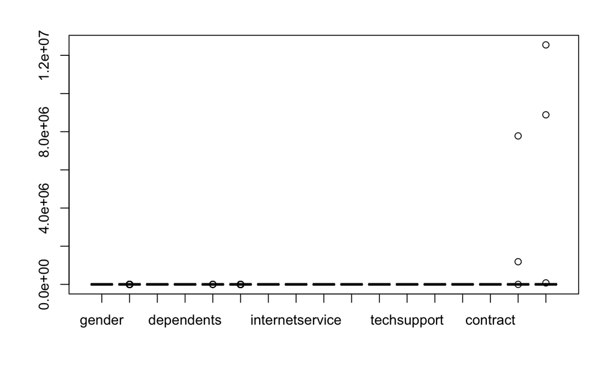

```r
# Use BoxPlot to detect outliers in the numeric/continuous data columns
boxplot(clean_df[,cols])
```

Observation: our dataset has outliers

Let’s create 2 helper functions, one to detect outliers and another to remove outliers

```r
detect_outlier <- function(x) {
  # calculate first quantile
  Q1 <- quantile(x, probs=.25)

  # calculate third quantile
  Q3 <- quantile(x, probs=.75)

  # calculate interquartile range
  IQR = Q3 - Q1

  # if an observation is greater than 1.5 times the third quantile or less than 1.5 times the first quantile, it returns true.
  x > Q3 + (IQR*1.5) | x < Q1 - (IQR*1.5)
}
```

```r
remove_outliers <- function(dataframe, columns=names(dataframe)) {
  # for loop to traverse in columns vector
  for (col in columns) {
    # remove observation if it satisfies outlier function
    dataframe <- dataframe[!detect_outlier(dataframe[[col]]), ]
  }

  # return dataframe
  return(dataframe)
}
```

```r
print("Shape before removing outliers")
```

```
[1] "Shape before removing outliers"
```

```r
print(dim(clean_df))
```

```
[1] 7003   19
```

```r
cols <- names(clean_df)
cols <- cols[-19]
cols <- cols[-1]

df_without_outliers <- remove_outliers(clean_df, cols)

print("Shape after removing outliers")
```

```
[1] "Shape after removing outliers"
```

```r
print(dim(df_without_outliers))
```

```
[1] 5283   19
```

```r
# Let's confirm that our new dataset doesn't have outliers
cols <- c(names(df_without_outliers))
cols <- cols[-19]
cols <- cols[-1]
cols
```

```
 [1] "gender"           "seniorcitizen"    "partner"          "dependents"       "tenure"           "phoneservice"
 [7] "multiplelines"    "internetservice"  "onlinesecurity"   "onlinebackup"     "deviceprotection" "techsupport"
[13] "streamingtv"      "streamingmovies"  "contract"         "monthlycharges"   "totalcharges"
```

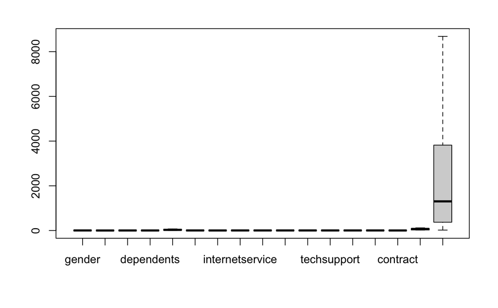

```r
# Use BoxPlot to detect outliers in the numeric/continuous data columns
boxplot(df_without_outliers[,cols])
```

Observation: all outliers are gone